# SBUX_store_channel_analysis

某连锁咖啡品牌渠道画像分析报告（FY26 P01）

一、引言说明 分析背景：主要目的是为了验证渠道和城市等级对业绩影响，找出高潜门店特征，为开店策略提供数据支持 数据说明：数据源database FY26 P01 截面数据，包含7991加在营门店（开业满3个月后稳定门店7696家） 关键指标：ADT(日均交易数)、AT（客单价）、面积、TZ(商圈/渠道)、城市等级（T1~T5） 分析方法：描述统计、方差分析（ANOVA）、事后检验（Tukey HSD）、双因素交互作用分析、相关性分析

*本报告基于个人学习目的，不涉及任何商业机密。分析方法和结论仅供参考

二、数据清洗与预处理

1. 导入数据，清洗格式
2. 筛选出已经开业满三个月的门店（即已经脱离蜜月期的业绩稳定门店）
3. 创建特征：坪效（adt_per_area）、渠道映射（基于定义的9类）、面积分组（小/中/大）
4. 处理_area/TZ 等异常值

```
<class 'pandas.core.frame.DataFrame'>
RangeIndex: 7991 entries, 0 to 7990
Columns: 122 entries, Number to FY26 YTD
Rent
dtypes: float64(70), int64(1), object(51)
memory usage: 7.4+ MB
```

```
_area
150       132
180       105
100        95
140        89
160        86
         ...
197.65      1
151.58      1
170.95      1
50.41       1
26.5        1
Name: count, Length: 3103, dtype: int64
```

```
<class 'pandas.core.frame.DataFrame'>
Index: 7742 entries, 0 to 7989
Data columns (total 12 columns):
 #   Column               Non-Null Count  Dtype
---  ------               --------------  -----
 0   Number               7742 non-null   int64
 1   Tier                 7742 non-null   object
 2   City_Cn              7742 non-null   object
 3   Store_Name_cn        7742 non-null   object
 4   open_date            7742 non-null   datetime64[ns]
 5   TZ                   7741 non-null   object
 6   TA                   7741 non-null   object
 7   _area                7742 non-null   object
 8   TA_Sub               7741 non-null   object
 9   FY26_P01_ADT         7697 non-null   object
 10  FY26_P01_AT          7700 non-null   float64
 11  months_since_opened  7742 non-null   float64
dtypes: datetime64[ns](1), float64(2), int64(1), object(8)
memory usage: 786.3+ KB
```

- 从上面显示可以看出TZ TA TA_Sub 是有一个缺失值的，由于这子商圈属于商圈属于商区，所以判断大概率属于同一家门店。我们先查看以验证判断是否准确。
- FY26_P01_ADT FY26_P01_AT 也有缺失值，按照通常情况ADT 缺失值数量应与 AT 一样，此份database 是所有在营门店的经营状况，所以不会有临时闭店的情况。所以对于这两列的缺失值还是需要分别单独查看。
- 下一步再看是否要对该缺失值进行补缺，也考虑到样本量比较充足，也会考虑直接删除有缺失值的门店。

|  | Number | _area |
| --- | --- | --- |
| 1642 | 56407 | - |
| 5088 | 54806 | - |
| 6050 | 64847 | - |
| 7433 | 81440 | - |

*'_area' 是其实是计租面积，在df['usable_area'] 其实也能看到这个值，可以尝试用'usable_area' 填补'_area'缺失值

```
      Number                    Usable_Area
1642   56407  248.00  (198.00; 0.00; 50.00)
5088   54806   181.00  (181.00; 0.00; 0.00)
6050   64847     84.00  (84.00; 0.00; 0.00)
7433   81440   160.00  (160.00; 0.00; 0.00)
```

# Usable_Area 我们只需要取到括号外面的值即可，打算用正则

|  | Number | _area |
| --- | --- | --- |
| 1642 | 56407 | 248.0 |
| 5088 | 54806 | 181.0 |
| 6050 | 64847 | 84.0 |
| 7433 | 81440 | 160.0 |

*查看TZ TA TA_sub 三个的缺失值 样本的情况，初步判断是同一家门店比较大

```
      Number              Store_Name_cn   TZ   TA TA_Sub
1041   54487  天津新汇华庭(Closed 2025-10-31)  NaN  NaN    NaN
```

已经关闭的门店和没有adt at 的门店对后面的分析没有意义，所以后续一并删除

```
<class 'pandas.core.frame.DataFrame'>
Index: 7696 entries, 0 to 7989
Data columns (total 12 columns):
 #   Column               Non-Null Count  Dtype
---  ------               --------------  -----
 0   Number               7696 non-null   int64
 1   Tier                 7696 non-null   object
 2   City_Cn              7696 non-null   object
 3   Store_Name_cn        7696 non-null   object
 4   open_date            7696 non-null   datetime64[ns]
 5   TZ                   7696 non-null   object
 6   TA                   7696 non-null   object
 7   _area                7696 non-null   object
 8   TA_Sub               7696 non-null   object
 9   FY26_P01_ADT         7696 non-null   object
 10  FY26_P01_AT          7696 non-null   float64
 11  months_since_opened  7696 non-null   float64
dtypes: datetime64[ns](1), float64(2), int64(1), object(8)
memory usage: 781.6+ KB
```

```
TZ
C3     2929
C2     1424
O      1043
R       723
C1      596
S       337
TS      297
CBD     181
T       166
Name: count, dtype: int64
```

```
TA
C        4882
O        1390
R         568
Other     380
TS        304
T         172
Name: count, dtype: int64
```

```
channel
社区型商业              2929
区域级商业区             1424
办公商圈（写字楼、园区）       1043
住宅                  723
市级商业中心区             596
特殊商圈（学校、医院、博物馆)     337
交通枢纽                297
keycity 大型综合商圈      181
旅游                  166
Name: count, dtype: int64
```

三、描述性统计分析：渠道与城市等级业绩概览

3.1 整体各个渠道ADT 业绩表现对比 各个渠道门店均值、中位数、标准差（groupby 列表）

| channel | mean | median | std |
| --- | --- | --- | --- |
| keycity 大型综合商圈 | 177.77 | 158.0 | 103.45 |
| 交通枢纽 | 376.65 | 298.0 | 318.86 |
| 住宅 | 158.41 | 148.0 | 62.87 |
| 办公商圈（写字楼、园区） | 152.71 | 138.0 | 80.60 |
| 区域级商业区 | 198.46 | 184.0 | 89.77 |
| 市级商业中心区 | 193.14 | 173.5 | 102.30 |
| 旅游 | 194.13 | 169.0 | 142.79 |
| 特殊商圈（学校、医院、博物馆) | 181.60 | 153.0 | 137.31 |
| 社区型商业 | 171.06 | 160.0 | 73.11 |

3.2 渠道箱线图与柱状图（附图表）

·交通枢纽门店ADT均值异常突出，但是数据分布大（波动大）；市级商业中心、区域级商业区表现稳定且ADT 较高

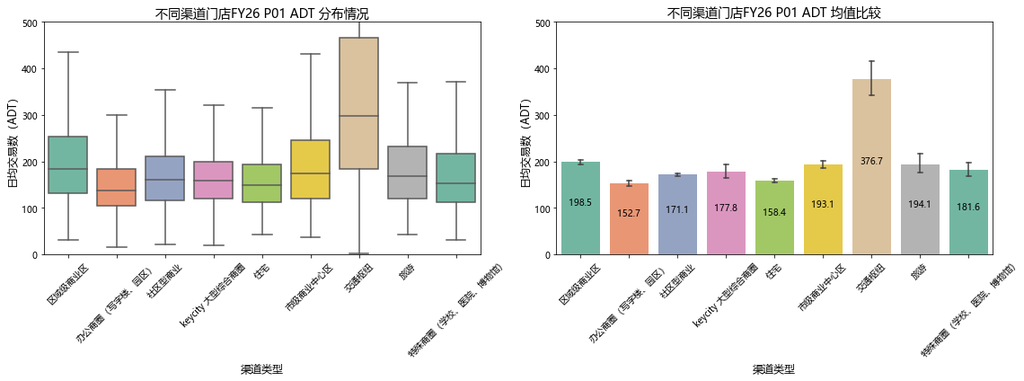

基于以上发现，需要对城市等级x渠道进行交叉分析，进行深入分析不同城市等级的各个渠道的区别

3.3 城市等级×渠道交叉分析（分组箱线图和柱状图）

·大多数渠道ADT 随城市等级下降而递减，但幅度不同 ·交通枢纽门店店均ADT在T1等级城市高达558，T5城市降至148，降幅最大；市级商业中心各等级城市表现平稳

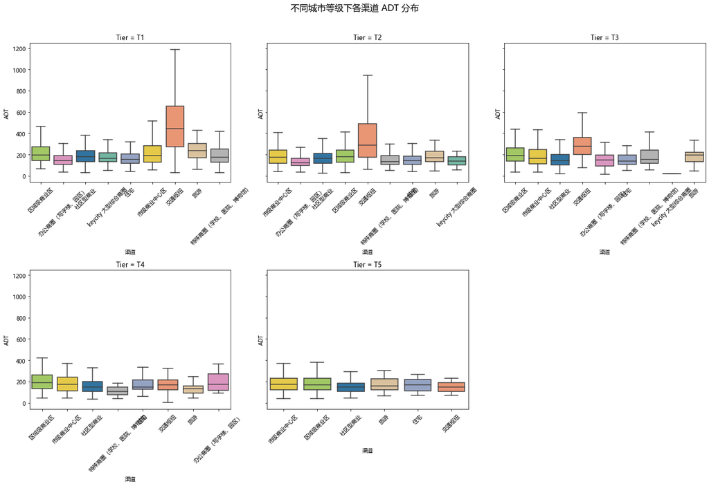

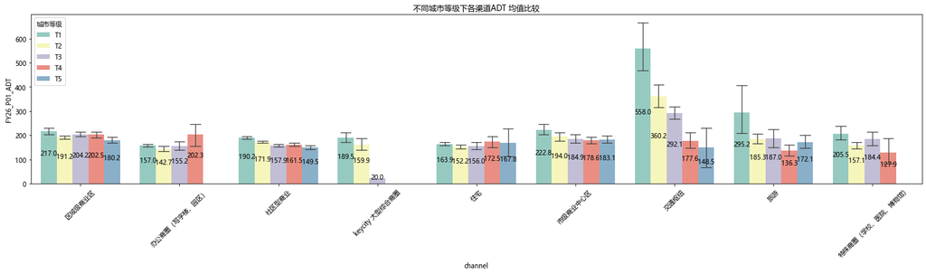

大多数渠道的ADT 随城市等级下降而递减，即T1城市ADT 最高，T5 城市最低，这也门店业绩与城市经济水平发展正相关的预期。

社区型商业，ADT 表现平稳，是各个等级城市可以布局的安全型渠道； 特殊商圈，整体ADT 表现水平较高； 办公商圈，T4等级城市ADT 优于T1等级城市，且表现不低；这里有待进一步分析门店业绩影响的因素 Keycity 大型综合商圈，这个渠道的ADT 均值结果有点让我意外，居然会低于市级商业中心区和区域级商业区，这里考虑可能性是门店之间互相分流以及城市中心竞品影响，待进一步分析以验证。

基于以上观察，下一步采用ANOVA 验证具体不同城市、不同渠道的门店ADT 均值差异显著程度。

四、统计验证：渠道与城市等级对ADT 影响

```
整体ANOVA：F = 151.774, p = 0.0000
```

```
                  sum_sq      df           F         PR(>F)
C(channel)  1.337661e+07     8.0  151.773752  3.857243e-238
Residual    8.468693e+07  7687.0         NaN            NaN
```

```
            Multiple Comparison of Means - Tukey HSD, FWER=0.05
===========================================================================
     group1          group2      meandiff p-adj    lower     upper   reject
---------------------------------------------------------------------------
 keycity 大型综合商圈            交通枢纽  198.8797    0.0  168.1715  229.5879   True
 keycity 大型综合商圈              住宅  -19.3655 0.3926  -46.4321    7.7012  False
 keycity 大型综合商圈    办公商圈（写字楼、园区）  -25.0602 0.0743  -51.2823     1.162  False
 keycity 大型综合商圈          区域级商业区   20.6837 0.2333   -5.0145   46.3818  False
 keycity 大型综合商圈         市级商业中心区   15.3624 0.7314  -12.2756   43.0004  False
 keycity 大型综合商圈              旅游    16.353 0.8783  -18.6439   51.3499  False
 keycity 大型综合商圈 特殊商圈（学校、医院、博物馆)     3.823    1.0  -26.1872   33.8332  False
 keycity 大型综合商圈           社区型商业   -6.7113 0.9958  -31.6538   18.2311  False
           交通枢纽              住宅 -218.2452    0.0 -240.6897 -195.8006   True
           交通枢纽    办公商圈（写字楼、园区） -223.9399    0.0 -245.3584 -202.5213   True
           交通枢纽          区域级商业区  -178.196    0.0 -198.9698 -157.4223   True
           交通枢纽         市级商业中心区 -183.5173    0.0 -206.6477 -160.3869   True
           交通枢纽              旅游 -182.5267    0.0 -214.0852 -150.9682   True
           交通枢纽 特殊商圈（学校、医院、博物馆) -195.0568    0.0 -220.9753 -169.1383   True
           交通枢纽           社区型商业 -205.5911    0.0 -225.4224 -185.7597   True
             住宅    办公商圈（写字楼、园区）   -5.6947 0.9712  -21.4542   10.0648  False
             住宅          区域级商业区   40.0491    0.0   25.1778   54.9205   True
             住宅         市级商业中心区   34.7279    0.0   16.7106   52.7451   True
             住宅              旅游   35.7185 0.0025    7.6909   63.7461   True
             住宅 特殊商圈（学校、医院、博物馆)   23.1884 0.0231    1.7088   44.6681   True
             住宅           社区型商业   12.6541  0.088   -0.8696   26.1778  False
   办公商圈（写字楼、园区）          区域级商业区   45.7438    0.0   32.4715   59.0161   True
   办公商圈（写字楼、园区）         市级商业中心区   40.4226    0.0   23.7008   57.1444   True
   办公商圈（写字楼、园区）              旅游   41.4132 0.0001   14.2002   68.6261   True
   办公商圈（写字楼、园区） 特殊商圈（学校、医院、博物馆)   28.8831 0.0004    8.4779   49.2883   True
   办公商圈（写字楼、园区）           社区型商业   18.3488    0.0    6.6063   30.0913   True
         区域级商业区         市级商业中心区   -5.3213 0.9821  -21.2088   10.5663  False
         区域级商业区              旅游   -4.3307 0.9999  -31.0391   22.3777  False
         区域级商业区 特殊商圈（学校、医院、博物馆)  -16.8607 0.1657   -36.588    2.8666  False
         区域级商业区           社区型商业   -27.395    0.0  -37.9156  -16.8745   True
        市级商业中心区              旅游    0.9906    1.0  -27.5892   29.5704  False
        市级商业中心区 特殊商圈（学校、医院、博物馆)  -11.5395  0.798  -33.7348   10.6558  False
        市级商业中心区           社区型商业  -22.0738 0.0001  -36.7075     -7.44   True
             旅游 特殊商圈（学校、医院、博物馆)  -12.5301 0.9429  -43.4098   18.3497  False
             旅游           社区型商业  -23.0644 0.1295  -49.0465    2.9178  False
特殊商圈（学校、医院、博物馆)           社区型商业  -10.5343 0.7186  -29.2666     8.198  False
---------------------------------------------------------------------------
```

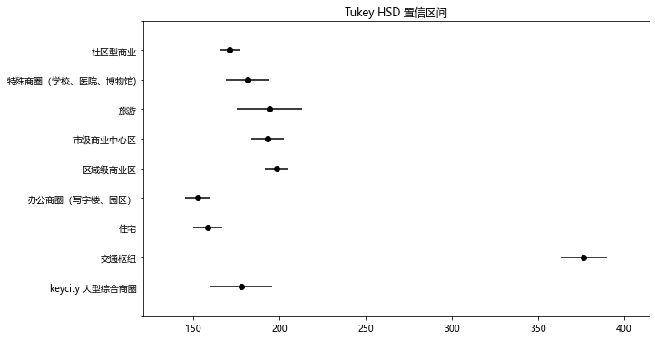

4.2 按城市等级分层 ANOVA

```
T1渠道 ANOVA: F = 94.734, p = 0.000

--- T1 内显著不同的渠道对 (Tukey HSD) ---
            group1           group2  meandiff   p-adj
0   keycity 大型综合商圈             交通枢纽  368.4800  0.0000
5   keycity 大型综合商圈               旅游  105.7244  0.0021
8             交通枢纽               住宅 -394.0349  0.0000
9             交通枢纽     办公商圈（写字楼、园区） -400.9459  0.0000
10            交通枢纽           区域级商业区 -340.9166  0.0000
11            交通枢纽          市级商业中心区 -335.1608  0.0000
12            交通枢纽               旅游 -262.7556  0.0000
13            交通枢纽  特殊商圈（学校、医院、博物馆) -352.4195  0.0000
14            交通枢纽            社区型商业 -367.7810  0.0000
16              住宅           区域级商业区   53.1183  0.0001
17              住宅          市级商业中心区   58.8741  0.0006
18              住宅               旅游  131.2793  0.0000
19              住宅  特殊商圈（学校、医院、博物馆)   41.6155  0.0303
21    办公商圈（写字楼、园区）           区域级商业区   60.0293  0.0000
22    办公商圈（写字楼、园区）          市级商业中心区   65.7850  0.0000
23    办公商圈（写字楼、园区）               旅游  138.1903  0.0000
24    办公商圈（写字楼、园区）  特殊商圈（学校、医院、博物馆)   48.5264  0.0009
25    办公商圈（写字楼、园区）            社区型商业   33.1649  0.0001
27          区域级商业区               旅游   78.1610  0.0483
33              旅游  特殊商圈（学校、医院、博物馆)  -89.6639  0.0147
34              旅游            社区型商业 -105.0254  0.0004
--------------------------------------------------
T2渠道 ANOVA: F = 62.320, p = 0.000

--- T2 内显著不同的渠道对 (Tukey HSD) ---
            group1           group2  meandiff   p-adj
0   keycity 大型综合商圈             交通枢纽  200.2870  0.0000
8             交通枢纽               住宅 -208.0308  0.0000
9             交通枢纽     办公商圈（写字楼、园区） -217.5484  0.0000
10            交通枢纽           区域级商业区 -169.0046  0.0000
11            交通枢纽          市级商业中心区 -166.2264  0.0000
12            交通枢纽               旅游 -174.9641  0.0000
13            交通枢纽  特殊商圈（学校、医院、博物馆) -203.1301  0.0000
14            交通枢纽            社区型商业 -188.3742  0.0000
16              住宅           区域级商业区   39.0262  0.0000
17              住宅          市级商业中心区   41.8044  0.0005
```

[output cut: 25 more lines]

```
--------------------------------------------------
T4渠道 ANOVA: F = 7.059, p = 0.000

--- T4 内显著不同的渠道对 (Tukey HSD) ---
    group1 group2  meandiff   p-adj
19  区域级商业区     旅游  -66.2532  0.0004
21  区域级商业区  社区型商业  -41.0472  0.0000
--------------------------------------------------
T5渠道 ANOVA: F = 5.002, p = 0.000

--- T5 内显著不同的渠道对 (Tukey HSD) ---
     group1 group2  meandiff   p-adj
11   区域级商业区  社区型商业  -30.6802  0.0004
13  市级商业中心区  社区型商业  -33.6144  0.0009
--------------------------------------------------
```

```
T1渠道 ANOVA: F = 94.734, p = 0.000
T1 渠道的字母标记：
           channel cld Tier
0   keycity 大型综合商圈   a   T1
1             交通枢纽   b   T1
2               住宅   a   T1
3     办公商圈（写字楼、园区）   a   T1
4           区域级商业区   a   T1
5          市级商业中心区   a   T1
6               旅游   c   T1
7  特殊商圈（学校、医院、博物馆)   a   T1
8            社区型商业   a   T1
--------------------------------------------------
T2渠道 ANOVA: F = 62.320, p = 0.000
T2 渠道的字母标记：
           channel cld Tier
0   keycity 大型综合商圈   a   T2
1             交通枢纽   b   T2
2               住宅   a   T2
3     办公商圈（写字楼、园区）   a   T2
4           区域级商业区   a   T2
5          市级商业中心区   a   T2
6               旅游   a   T2
7  特殊商圈（学校、医院、博物馆)   a   T2
8            社区型商业   a   T2
--------------------------------------------------
T3渠道 ANOVA: F = 28.108, p = 0.000
T3 渠道的字母标记：
           channel cld Tier
0   keycity 大型综合商圈   a   T3
1             交通枢纽   b   T3
2               住宅   a   T3
3     办公商圈（写字楼、园区）   a   T3
4           区域级商业区   a   T3
5          市级商业中心区   a   T3
6               旅游   a   T3
7  特殊商圈（学校、医院、博物馆)   a   T3
8            社区型商业   a   T3
--------------------------------------------------
T4渠道 ANOVA: F = 7.059, p = 0.000
T4 渠道的字母标记：
           channel cld Tier
0             交通枢纽   a   T4
1               住宅   a   T4
2     办公商圈（写字楼、园区）   a   T4
3           区域级商业区   a   T4
4          市级商业中心区   a   T4
5               旅游   a   T4
6  特殊商圈（学校、医院、博物馆)   a   T4
7            社区型商业   a   T4
--------------------------------------------------
T5渠道 ANOVA: F = 5.002, p = 0.000
T5 渠道的字母标记：
   channel cld Tier
0     交通枢纽   a   T5
1       住宅   a   T5
2   区域级商业区   a   T5
3  市级商业中心区   a   T5
4       旅游   a   T5
5    社区型商业   a   T5
--------------------------------------------------
```

4.3 双因素ANOVA（渠道×城市等级）

·由于部分渠道在一些等级城市没有门店（如Keycity 在T4/T5 为0，其原因是大型综合商圈的定义范围只在T1/T2），模型出现矩阵警告，交互项P=0.226不显著 ·结合图形，交互作用仍然存在业务意义，交通枢纽店对城市等级的敏感度极高

```
                          sum_sq      df          F        PR(>F)
C(channel)          2.819873e+06     8.0  34.298518  2.083907e-47
C(Tier)            -5.194110e+00     4.0  -0.000126  1.000000e+00
C(channel):C(Tier)  4.820079e+05    32.0   1.465683  2.260655e-01
Residual            7.867006e+07  7655.0        NaN           NaN
                            OLS Regression Results
==============================================================================
Dep. Variable:           FY26_P01_ADT   R-squared:                       0.198
Model:                            OLS   Adj. R-squared:                  0.194
Method:                 Least Squares   F-statistic:                     47.18
Date:                Fri, 20 Mar 2026   Prob (F-statistic):               0.00
Time:                        13:41:00   Log-Likelihood:                -46446.
No. Observations:                7696   AIC:                         9.297e+04
Df Residuals:                    7655   BIC:                         9.326e+04
Df Model:                          40
Covariance Type:            nonrobust
===============================================================================================================
                                                  coef    std err          t      P>|t|      [0.025      0.975]
---------------------------------------------------------------------------------------------------------------
Intercept                                     189.1462      9.499     19.913      0.000     170.526     207.766
C(channel)[T.交通枢纽]                            367.9719     14.791     24.877      0.000     338.977     396.967
C(channel)[T.住宅]                              -25.9673     11.212     -2.316      0.021     -47.945      -3.989
C(channel)[T.办公商圈（写字楼、园区）]                    -32.6024     10.355     -3.148      0.002     -52.902     -12.303
C(channel)[T.区域级商业区]                           25.9468     11.793      2.200      0.028       2.829      49.064
C(channel)[T.市级商业中心区]                          30.9307     13.378      2.312      0.021       4.706      57.156
C(channel)[T.旅游]                              103.5407     21.161      4.893      0.000      62.060     145.022
C(channel)[T.特殊商圈（学校、医院、博物馆)]                  15.8922     12.579      1.263      0.206      -8.766      40.550
C(channel)[T.社区型商业]                            -0.1209     10.199     -0.012      0.991     -20.114      19.872
C(Tier)[T.T2]                                 -28.4664     15.705     -1.813      0.070     -59.253       2.320
C(Tier)[T.T3]                                -168.5405    101.822     -1.655      0.098    -368.139      31.058
C(Tier)[T.T4]                               -9.454e+12   7.81e+12     -1.211      0.226   -2.48e+13    5.85e+12
C(Tier)[T.T5]                               -4.204e+14   3.47e+14     -1.211      0.226    -1.1e+15     2.6e+14
C(channel)[T.交通枢纽]:C(Tier)[T.T2]             -167.9944     21.709     -7.738      0.000    -210.551    -125.438
C(channel)[T.住宅]:C(Tier)[T.T2]                 18.1402     17.714      1.024      0.306     -16.584      52.865
C(channel)[T.办公商圈（写字楼、园区）]:C(Tier)[T.T2]       15.6690     17.098      0.916      0.359     -17.849      49.187
C(channel)[T.区域级商业区]:C(Tier)[T.T2]              4.0173     17.693      0.227      0.820     -30.667      38.701
C(channel)[T.市级商业中心区]:C(Tier)[T.T2]             1.4076     20.166      0.070      0.944     -38.123      40.938
C(channel)[T.旅游]:C(Tier)[T.T2]                -79.2582     27.742     -2.857      0.004    -133.640     -24.877
C(channel)[T.特殊商圈（学校、医院、博物馆)]:C(Tier)[T.T2]   -18.5522     19.752     -0.939      0.348     -57.271      20.167
C(channel)[T.社区型商业]:C(Tier)[T.T2]              11.3402     16.406      0.691      0.489     -20.820      43.500
```

[output cut: 20 more lines]

```
C(channel)[T.市级商业中心区]:C(Tier)[T.T5]          4.204e+14   3.47e+14      1.211      0.226    -2.6e+14     1.1e+15
C(channel)[T.旅游]:C(Tier)[T.T5]               4.204e+14   3.47e+14      1.211      0.226    -2.6e+14     1.1e+15
C(channel)[T.特殊商圈（学校、医院、博物馆)]:C(Tier)[T.T5]          0          0        nan        nan           0           0
C(channel)[T.社区型商业]:C(Tier)[T.T5]            4.204e+14   3.47e+14      1.211      0.226    -2.6e+14     1.1e+15
==============================================================================
Omnibus:                     8095.833   Durbin-Watson:                   1.847
Prob(Omnibus):                  0.000   Jarque-Bera (JB):          2181431.919
Skew:                           4.747   Prob(JB):                         0.00
Kurtosis:                      84.931   Cond. No.                     1.22e+16
==============================================================================

Notes:
[1] Standard Errors assume that the covariance matrix of the errors is correctly specified.
[2] The smallest eigenvalue is 7.68e-29. This might indicate that there are
strong multicollinearity problems or that the design matrix is singular.
```

[output not shown]

```
['Number',
 'Tier',
 'City_Cn',
 'Store_Name_cn',
 'open_date',
 'TZ',
 'TA',
 '_area',
 'TA_Sub',
 'FY26_P01_ADT',
 'FY26_P01_AT',
 'months_since_opened',
 'adt_per_area',
 'channel']
```

```
已成功导出channel_tier_summary
```

```
     group1 group2  meandiff   p-adj    lower   upper  reject
11   区域级商业区  社区型商业  -30.6802  0.0004 -51.5499 -9.8105    True
13  市级商业中心区  社区型商业  -33.6144  0.0009 -57.4099 -9.8190    True
```

```
ShapiroResult(statistic=0.7800338425671298, pvalue=1.04981695710617e-72)
```

·通过以上分析，可以证明channel 和Tier 对于门店模型来说是必须要加入的条件，尤其是channel，不同的渠道门店ADT 均值差异显著。 ·这当中会涉及到几个问题，从业务经验角度看，不同渠道之间的店均ADT 肯定是不同的，但是ANOVA 方差分析，给这个业务经验提供了统计支撑 ·也就是说，ANOVA 检验能够说明不同渠道之间的店均ADT 差异程度，将上述的业务经验进行量化，整体ANOVA：F = 151.774, p = 0.0000 ·下一步，计划用ANOVA 对面积进行检验，查看不同面积的门店业绩是否差异显著，以此判断是否要加入模型构成条件。

五、面积对ADT 的影响

5.1 面积分组ANOVA ·将面积等分为三类（小中大），ANOVA 显示组间差异显著（F=125.3， P≈0） ·Tukey 检验：大面积店ADT 显著高于中面积和小面积（约高36~47）

```
面积分组ANOVA：F=125.275, P=0.0000
```

```
 Multiple Comparison of Means - Tukey HSD, FWER=0.05
======================================================
group1 group2 meandiff p-adj   lower    upper   reject
------------------------------------------------------
 中面积门店  大面积门店   36.353    0.0  29.0795  43.6266   True
 中面积门店  小面积门店  -10.461 0.0021 -17.7282  -3.1939   True
 大面积门店  小面积门店 -46.8141    0.0 -54.0905 -39.5377   True
------------------------------------------------------
相关性P 值 = 0.0000
在显著水平α=0.05 下，相关性显著
```

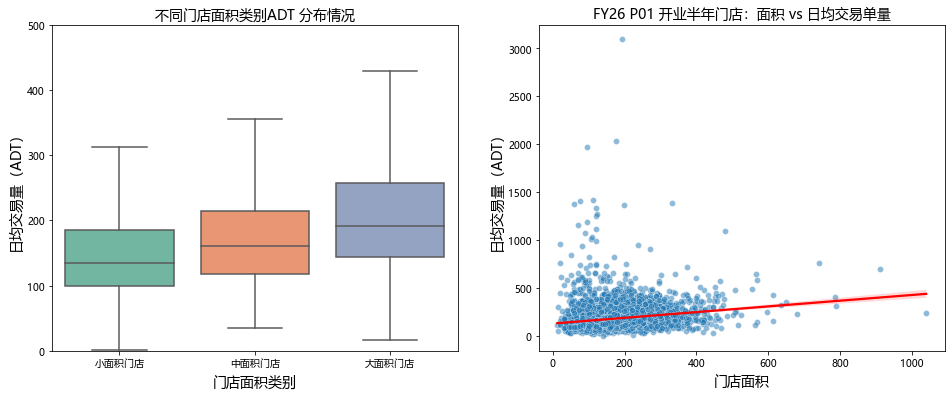

| Tier channel | T1 | T2 | T3 | T4 | T5 |
| --- | --- | --- | --- | --- | --- |
| keycity 大型综合商圈 | 114 | 66 | 1 | 0 | 0 |
| 交通枢纽 | 80 | 106 | 82 | 27 | 2 |
| 住宅 | 290 | 317 | 75 | 35 | 6 |
| 办公商圈（写字楼、园区） | 602 | 351 | 75 | 15 | 0 |
| 区域级商业区 | 218 | 514 | 302 | 227 | 163 |
| 市级商业中心区 | 121 | 136 | 117 | 115 | 107 |
| 旅游 | 29 | 61 | 24 | 30 | 22 |
| 特殊商圈（学校、医院、博物馆) | 151 | 135 | 43 | 8 | 0 |
| 社区型商业 | 766 | 1042 | 591 | 311 | 219 |

[figure not shown]

5.3 各个城市等级的面积-ADT 散点图

·各等级内，不同渠道的点分布模式相似：交通枢纽店集中在高ADT区域，社区店分散在低ADT 区域 ·面积与ADT 正相关趋势在所有等级城市都存在，但是斜率有不同

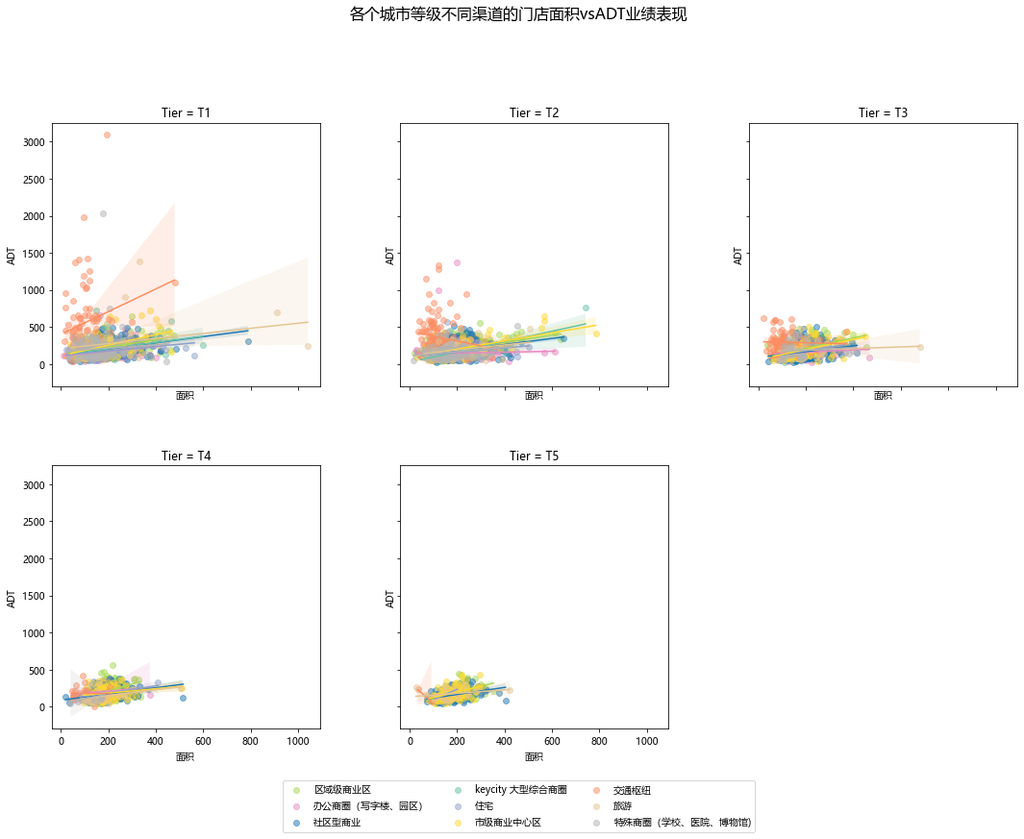

六、结论与业务建议

6.2 业务建议

·存量店优化调整： ·对交通枢纽中的低业绩门店，深入分析原因（面积、位置、竞品等等） ·对于社区店中面积过大的门店，考虑坪效优化

·可深化分析 ·引入租金数据，分析‘收入-租金成本’性价比，寻找高业绩低租金门店 ·动态分析（加入多期数据）观察渠道业绩稳定性与趋势 ·聚类分析，探索数据驱动的渠道新分类